# Analyzing Bangladeshi Election Data

*Nasheya Rahman*

The goal of this project is to analyze Bangladeshi election data and figure out what kinds of factors may have contributed to certain liberal or conservative parties being elected. There are two main parties in Bangladesh - Bangladesh Nationalist Party (BNP) and Awami League. BNP is significantly more conservative than Awami League, and the elections that BNP was elected may reflect the rising conservatism in Bangladesh.

The factors I’ll be looking at are urbanization and labor migrant populations. In the future, I hope to look at education levels and religiousness in the country. The goal is to be able to explain the differences in the parties elected from one election to another and then possibly be able to forecast to see what the future would look like.

Of course, politics are very nuanced, especially in a country like Bangladesh where there may be voter fraud going on and the election system is, essentially, considered to be broken. This project is more supposed to be some kind of preliminary analysis because the deeper analysis would be something more like what a PhD student would do.

## Libraries

```r
library(readr)
library(dplyr)
```

```r
library(ggplot2)
library(viridis)
```

# Political Parties

Just a small lesson on the political parties of Bangladesh and what they mean.

### Awami League

One of the two major parties in Bangladesh. They’re the left-wing, secular, democratic party of Bangladesh.

### Bangladesh Nationalist Party (BNP)

This is the other major party in Bangladesh. They’re the right-wing, conservative party of Bangladesh.

### Jamaat-e-Islami Party

This is the largest Islamist party in Bangladesh and they strongly opposed the independence from Pakistan because they believe that Islamic nations should be united. They were considered unfit to participate in national elections as they were, so they had to revamp their party.

### Jatiya Party

Historically conservative, Jatiya Party splintered off into two groups - one right-wing and one left-wing after there was a disagreement of the chairs of the party.

### Grand Alliance (Mohajote) and 18-Party Alliance

These are the current day major parties, and they’re led by Awami League and BNP, respectively. They’re both coalitions of parties that started collaborating and conglomerating. 4-Party Alliance is the predecessor of 18-Party Alliance.

# Data

In my data, I’m going to divide the data up into conservative and liberal. Under conservative will be the 18-Party Alliance parties and under liberal will be the Grand Alliance parties. Under Grand Alliance, I am considering the tags Awami League and Mohajote. Under 18-Party Alliance, I am considering BNP, Jatiya Party, Jamaat-e-Islami Party, and 4-Party Alliance.

## Election Data

For the election data, I’ll be looking at parliamentary elections. I have data for 4 different elections and the 1996 6th parliamentary election and the 2014 election data is missing. Whenever the data was missing though, it was when most of the opposition parties boycotted the elections, so a party ended up winning almost by default.

```r
election1991 <- read_csv("/Users/nasheyarahman/Desktop/stat395-labs-nasheya/Final Project/Bangladesh1991ElectionResults.csv")
election1996 <- read_csv("/Users/nasheyarahman/Desktop/stat395-labs-nasheya/Final Project/Bangladesh1996ElectionResults.csv")
election2001 <- read_csv("/Users/nasheyarahman/Desktop/stat395-labs-nasheya/Final Project/Bangladesh2001ElectionResults.csv")
election2008 <- read_csv("/Users/nasheyarahman/Desktop/stat395-labs-nasheya/Final Project/Bangladesh2008ElectionResults.csv")
```

All the data is not consistently formatted, so here I am formatting it.

```r
election2008$winner[election2008$winner == "MOHAJOTE"] <- "MJ"
election2008$winner[election2008$winner == "others"] <- "Others"
```

In order to do this analysis, I will construct a new data table with year, each district, the number of chairs for each ideaology in that year, and the corresponding percentages of votes each ideaology got.

```r
liberal <- c("AL", "MJ")
conservative <- c("BNP", "JIB", "JP", "4P")
```

1991 Election Data:

```r
attach(election1991)
election1991_temp <- aggregate(election1991[c(-1:-5, seq(-7, -17, by = -2), -18)], by = list(election1991$district), FUN=sum, na.rm=TRUE)
colnames(election1991_temp) = c("district", "total_votes", "AL_votes", "BNP_votes", "JP_votes", "JIB_votes", "others_votes")

election1991_temp$conservative_percent_1991 <- (election1991_temp$BNP_votes + election1991_temp$JIB_votes + election1991_temp$JP_votes)/election1991_temp$total_votes
election1991_temp$liberal_percent_1991 <- election1991_temp$AL_votes/election1991_temp$total_votes
election1991_temp$other_percent_1991 <- election1991_temp$others_votes/election1991_temp$total_votes
election1991_temp$conservative_chairs_1991 <- 0
election1991_temp$liberal_chairs_1991 <- 0
election1991_temp$other_chairs_1991 <- 0

districts_1991 <- election1991_temp$district

for(i in districts_1991){
  temp <- table(election1991$winner[election1991$district == i])

  for(j in names(temp)){
    tempNum <- temp[j]
    if(j %in% liberal){
      election1991_temp$liberal_chairs_1991[election1991_temp$district == i] <- election1991_temp$liberal_chairs_1991[election1991_temp$district == i] + tempNum
    } else if(j %in% conservative){
      election1991_temp$conservative_chairs_1991[election1991_temp$district == i] <- election1991_temp$conservative_chairs_1991[election1991_temp$district == i] + tempNum
    } else {
      election1991_temp$other_chairs_1991[election1991_temp$district == i] <- election1991_temp$other_chairs_1991[election1991_temp$district == i] + tempNum
    }
  }
}

detach(election1991)
```

1996 Election Data:

```r
attach(election1996)
election1996_temp <- aggregate(election1996[c(-1:-5, seq(-7, -17, by = -2), -18)], by = list(election1996$district), FUN=sum, na.rm=TRUE)
colnames(election1996_temp) = c("district", "total_votes", "AL_votes", "BNP_votes", "JP_votes", "JIB_votes", "others_votes")

election1996_temp$conservative_percent_1996 <- (election1996_temp$BNP_votes + election1996_temp$JIB_votes + election1996_temp$JP_votes)/election1996_temp$total_votes
election1996_temp$liberal_percent_1996 <- election1996_temp$AL_votes/election1996_temp$total_votes
election1996_temp$other_percent_1996 <- election1996_temp$others_votes/election1996_temp$total_votes
election1996_temp$conservative_chairs_1996 <- 0
election1996_temp$liberal_chairs_1996 <- 0
election1996_temp$other_chairs_1996 <- 0

districts_1996 <- election1996_temp$district

for(i in districts_1996){
  temp <- table(election1996$winner[election1996$district == i])

  for(j in names(temp)){
    tempNum <- temp[j]
    if(j %in% liberal){
      election1996_temp$liberal_chairs_1996[election1996_temp$district == i] <- election1996_temp$liberal_chairs_1996[election1996_temp$district == i] + tempNum
    } else if(j %in% conservative){
      election1996_temp$conservative_chairs_1996[election1996_temp$district == i] <- election1996_temp$conservative_chairs_1996[election1996_temp$district == i] + tempNum
    } else {
      election1996_temp$other_chairs_1996[election1996_temp$district == i] <- election1996_temp$other_chairs_1996[election1996_temp$district == i] + tempNum
    }
  }
}

detach(election1996)
```

2001 Election Data:

```r
attach(election2001)
election2001_temp <- aggregate(election2001[c(-1:-5, seq(-7, -15, by = -2), -16)], by = list(election2001$district), FUN=sum, na.rm=TRUE)
colnames(election2001_temp) = c("district", "total_votes", "FOURP_votes", "AL_votes", "JP_votes", "others_votes")

election2001_temp$conservative_percent_2001 <- (election2001_temp$FOURP_votes + election2001_temp$JP_votes)/election2001_temp$total_votes
election2001_temp$liberal_percent_2001 <- election2001_temp$AL_votes/election2001_temp$total_votes
election2001_temp$other_percent_2001 <- election2001_temp$others_votes/election2001_temp$total_votes
election2001_temp$conservative_chairs_2001 <- 0
election2001_temp$liberal_chairs_2001 <- 0
election2001_temp$other_chairs_2001 <- 0

districts_2001 <- election2001_temp$district

for(i in districts_2001){
  temp <- table(election2001$winner[election2001$district == i])

  for(j in names(temp)){
    tempNum <- temp[j]
    if(j %in% liberal){
      election2001_temp$liberal_chairs_2001[election2001_temp$district == i] <- election2001_temp$liberal_chairs_2001[election2001_temp$district == i] + tempNum
    } else if(j %in% conservative){
      election2001_temp$conservative_chairs_2001[election2001_temp$district == i] <- election2001_temp$conservative_chairs_2001[election2001_temp$district == i] + tempNum
    } else {
      election2001_temp$other_chairs_2001[election2001_temp$district == i] <- election2001_temp$other_chairs_2001[election2001_temp$district == i] + tempNum
    }
  }
}

detach(election2001)
```

2008 Election Data:

```r
attach(election2008)
election2008_temp <- aggregate(election2008[c(-1:-5, seq(-7, -21, by = -2), -23)], by = list(election2008$district), FUN=sum, na.rm=TRUE)
colnames(election2008_temp) = c("district", "total_votes", "FOURP_votes", "MJ_votes", "AL_votes", "BNP_votes", "JP_votes", "JIB_votes", "others_votes", "blank_votes")

election2008_temp$conservative_percent_2008 <- (election2008_temp$FOURP_votes + election2008_temp$JP_votes + election2008_temp$BNP_votes + election2008_temp$JIB_votes)/election2008_temp$total_votes
election2008_temp$liberal_percent_2008 <- (election2008_temp$AL_votes + election2008_temp$MJ_votes)/election2008_temp$total_votes
election2008_temp$other_percent_2008 <- (election2008_temp$others_votes + election2008_temp$blank_votes)/election2008_temp$total_votes
election2008_temp$conservative_chairs_2008 <- 0
election2008_temp$liberal_chairs_2008 <- 0
election2008_temp$other_chairs_2008 <- 0

districts_2008 <- election2008_temp$district

for(i in districts_2008){
  temp <- table(election2008$winner[election2008$district == i])

  for(j in names(temp)){
    tempNum <- temp[j]
    if(j %in% liberal){
      election2008_temp$liberal_chairs_2008[election2008_temp$district == i] <- election2008_temp$liberal_chairs_2008[election2008_temp$district == i] + tempNum
    } else if(j %in% conservative){
      election2008_temp$conservative_chairs_2008[election2008_temp$district == i] <- election2008_temp$conservative_chairs_2008[election2008_temp$district == i] + tempNum
    } else {
      election2008_temp$other_chairs_2008[election2008_temp$district == i] <- election2008_temp$other_chairs_2008[election2008_temp$district == i] + tempNum
    }
  }
}

detach(election2008)
```

Total Election Counts

```r
total1991 <- c(1991, sum(election1991_temp$BNP_votes, election1991_temp$JIB_votes, election1991_temp$JP_votes)/sum(election1991_temp$total_votes), sum(election1991_temp$AL_votes)/sum(election1991_temp$total_votes), sum(election1991_temp$others_votes)/sum(election1991_temp$total_votes), sum(election1991_temp$conservative_chairs_1991), sum(election1991_temp$liberal_chairs_1991), sum(election1991_temp$other_chairs_1991))

total1996 <- c(1996, sum(election1996_temp$BNP_votes, election1996_temp$JIB_votes,  election1996_temp$JP_votes)/sum(election1996_temp$total_votes), sum(election1996_temp$AL_votes)/sum(election1996_temp$total_votes), sum(election1996_temp$others_votes)/sum(election1996_temp$total_votes), sum(election1996_temp$conservative_chairs_1996), sum(election1996_temp$liberal_chairs_1996), sum(election1996_temp$other_chairs_1996))

total2001 <- c(2001, sum(election2001_temp$FOURP_votes,  election2001_temp$JP_votes)/sum(election2001_temp$total_votes), sum(election2001_temp$AL_votes)/sum(election2001_temp$total_votes), sum(election2001_temp$others_votes)/sum(election2001_temp$total_votes), sum(election2001_temp$conservative_chairs_2001), sum(election2001_temp$liberal_chairs_2001), sum(election2001_temp$other_chairs_2001))

total2008 <- c(2008, sum(election2008_temp$FOURP_votes, election2008_temp$JP_votes,  election2008_temp$BNP_votes, election2008_temp$JIB_votes)/sum(election2008_temp$total_votes), sum(election2008_temp$AL_votes, election2008_temp$MJ_votes)/sum(election2008_temp$total_votes), sum(election2008_temp$others_votes, election2008_temp$blank_votes)/sum(election2008_temp$total_votes), sum(election2008_temp$conservative_chairs_2008), sum(election2008_temp$liberal_chairs_2008), sum(election2008_temp$other_chairs_2008))

electionTotal <- rbind(total1991, total1996, total2001, total2008)
colnames(electionTotal) <- c("year", "conservative_percent", "liberal_percent", "other_percent", "conservative_chairs", "liberal_chairs", "other_chairs")

electionTotal
```

```
##           year conservative_percent liberal_percent other_percent
## total1991 1991            0.5486128       0.3372475    0.11413972
## total1996 1996            0.5861608       0.3744396    0.03939962
## total2001 2001            0.5409394       0.4012714    0.05778920
## total2008 2008            0.3904917       0.5506706    0.05856564
##           conservative_chairs liberal_chairs other_chairs
## total1991                 169             92           23
## total1996                 150            144            6
## total2001                 229             59           12
## total2008                  33            261            6
```

Now I’m removing information I don’t want in my merged dataset

```r
election1991_temp <- election1991_temp[-2:-7]
election1996_temp <- election1996_temp[-2:-7]
election2001_temp <- election2001_temp[-2:-6]
election2008_temp <- election2008_temp[-2:-10]
```

## Urbanization

```r
district_pop <- read_csv("/Users/nasheyarahman/Desktop/stat395-labs-nasheya/Final Project/DistrictPopulations.csv")
division_pop <- read_csv("/Users/nasheyarahman/Desktop/stat395-labs-nasheya/Final Project/DivisionPopulations.csv")
```

For the urbanization data, I have the district census populations from 1991, 2001, and 2011 and the division and country populations every 10 years from 1901 to 2011. The numbers are in millions. If we look at the district populations ranks though, we see that most districts stayed very close to what they initially were, so it looks like the population ratios didn’t change that much.

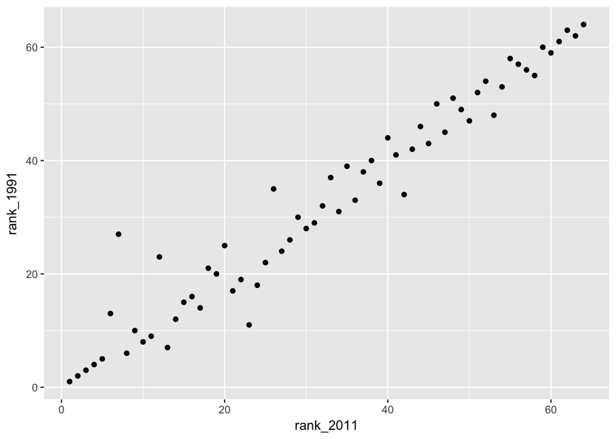

```r
qplot(rank_2011, rank_1991, data = district_pop)
```

However, a lot of information is lost with ranks. For example, Dhaka (the capital) is always rank #1, but that doesn’t tell you how much more people moved to Dhaka than from the rural areas.

In order to try and measure urbanization, I’m looking at the percentage change of the percent total of the population. So, for example, if in 1991 district A was 10% of the total population and in 2011, it was 5%, that means that the percentage change in the percentages of the total population at the time is -50%.

```r
slope1 = (district_pop$pop_2001 - district_pop$pop_1991)/10
intercept1 = district_pop$pop_1991 - 1991*slope1

for(i in seq(1991, 2001)){
  ratio <- paste("ratio", i, sep="_")
  pop <- paste("pop", i, sep="_")
  district_pop[, pop] <- slope1*i + intercept1
  district_pop[, ratio] <- district_pop[, pop]/sum(district_pop[, pop])
}

slope2 = (district_pop$pop_2011 - district_pop$pop_2001)/10
intercept2 = district_pop$pop_2001 - 2001*slope2

for(i in seq(2002, 2011)){
  ratio <- paste("ratio", i, sep="_")
  pop <- paste("pop", i, sep="_")
  district_pop[, pop] <- slope2*i + intercept2
  district_pop[, ratio] <- district_pop[, pop]/sum(district_pop[, pop])
}

electionYears <- c(1996, 2001, 2008)
iPast <- 1991

for(i in electionYears){
  ratio <- paste("ratio", i, sep="_")
  ratioPast <- paste("ratio", iPast, sep="_")
  district_pop[, paste("percent_change", iPast, i, sep="_")] = (district_pop[, ratio]- district_pop[, ratioPast])/ district_pop[, ratioPast]
  iPast <- i
}
```

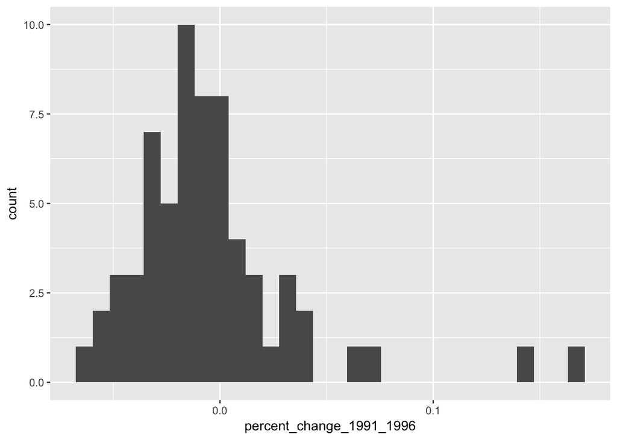

```r
qplot(percent_change_1991_1996, data = district_pop)
```

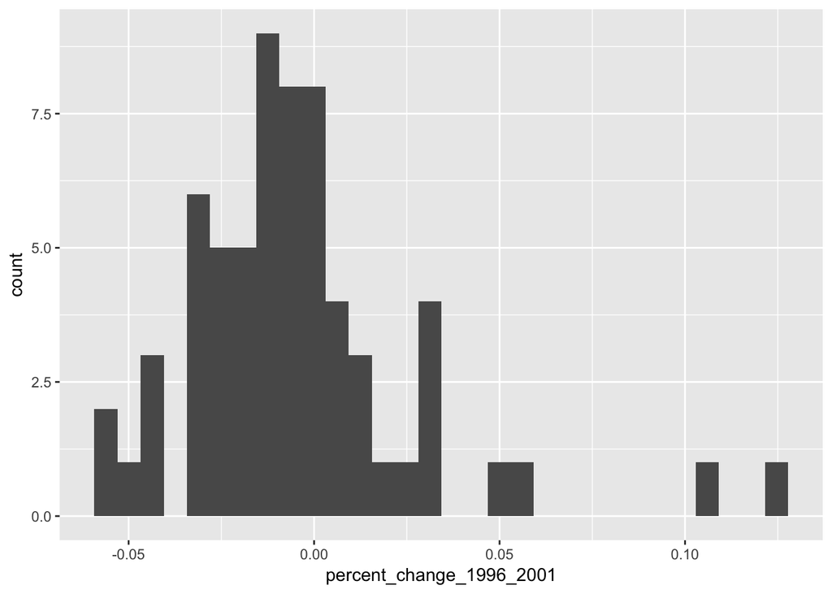

```r
qplot(percent_change_1996_2001, data = district_pop)
```

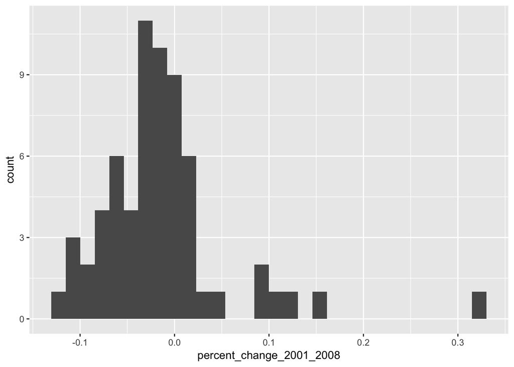

```r
qplot(percent_change_2001_2008, data = district_pop)
```

## Labor Migrant Populations

This data has the labor migrant populations from Bangladesh in various countries from 1976 to 2017.

```r
labor_migrant <- read_csv("/Users/nasheyarahman/Desktop/stat395-labs-nasheya/Final Project/LaborMigrantPopulations.csv")
```

# Analysis

First, I merged the datasets on the districts to do district analysis. Unfortunately, a lot of information was lost because there seemed to have been redistricting and renaming. So 41 out of the original 60 or so were preserved.

```r
merged <- merge(election1991_temp, election1996_temp, by = "district")
merged <- merge(merged, election2001_temp, by = "district")
merged <- merge(merged, election2008_temp, by = "district")
merged <- merge(merged, district_pop[,c(2,48,49,50)], by.x = "district", by.y = "District")
```

```r
merged$conservative_chairs_1991_1996 <- merged$conservative_chairs_1996 - merged$conservative_chairs_1991

library(gam)
model <- gam(conservative_chairs_1991_1996 ~ percent_change_1991_1996, data = merged)
merged$conservative_chairs_pred_change_1996 <- predict(model, newdata = merged)
sqrt(tapply((merged$conservative_chairs_pred_change_1996 - merged$conservative_chairs_1991_1996)^2, merged$district, mean))
```

```
##    Bagerhat       Bhola       Bogra  Chittagong     Comilla Cox's Bazar
##  2.43458786  2.34616976  0.18619068  4.12330222  3.74210525  2.17316881
##       Dhaka    Dinajpur    Faridpur        Feni   Gaibandha     Gazipur
##  3.67169603  0.52373344  1.37959325  0.09697691  0.83295290  0.75872262
##   Gopalganj    Jamalpur     Jessore   Jhenaidah   Joypurhat      Khulna
##  0.23447314  1.83880382  0.45372584  0.39866671  0.05681353  1.42172330
##    Kurigram     Kushtia Lalmonirhat   Madaripur   Manikganj    Meherpur
##  0.90302309  3.44957064  0.43039354  0.49709739  0.08153771  0.85111578
##  Munshiganj  Mymensingh     Naogaon      Narail      Natore  Nilphamari
##  0.24241673  1.85774734  2.00894316  0.59383831  0.84404314  4.40908564
##    Noakhali       Pabna  Patuakhali     Rajbari    Rajshahi     Rangpur
##  1.42823395  3.86924876  0.64510688  0.81502777  1.82357496  0.55247003
##  Shariatpur     Sherpur      Sylhet     Tangail  Thakurgaon
##  0.23862247  1.96912953  2.31316840  2.21843192  0.79589780
```

```r
range(merged$conservative_chairs_1991_1996)
```

```
## [1] -7  4
```

```r
mean(merged$conservative_chairs_1991_1996)
```

```
## [1] -0.3414634
```

```r
median(merged$conservative_chairs_1991_1996)
```

```
## [1] 0
```

```r
merged$conservative_chairs_1996_2001 <- merged$conservative_chairs_2001 - merged$conservative_chairs_1996

library(gam)
model <- gam(conservative_chairs_1996_2001 ~ percent_change_1996_2001, data = merged)
merged$conservative_chairs_pred_change_2001 <- predict(model, newdata = merged)
sqrt(tapply((merged$conservative_chairs_pred_change_2001 - merged$conservative_chairs_1996_2001)^2, merged$district, mean))
```

```
##    Bagerhat       Bhola       Bogra  Chittagong     Comilla Cox's Bazar
##  1.82365722  0.67305354  1.09872436  1.38453009  5.79852099  1.44964134
##       Dhaka    Dinajpur    Faridpur        Feni   Gaibandha     Gazipur
##  2.01148434  2.42407495  1.37415722  0.31459347  1.58123491  1.53805870
##   Gopalganj    Jamalpur     Jessore   Jhenaidah   Joypurhat      Khulna
##  0.48026857  1.93727235  3.39278837  2.40102644  0.91138864  2.34849110
##    Kurigram     Kushtia Lalmonirhat   Madaripur   Manikganj    Meherpur
##  0.68540653  1.47248098  2.44560527  0.08007472  0.70825708  1.02343310
##  Munshiganj  Mymensingh     Naogaon      Narail      Natore  Nilphamari
##  0.46832632  0.96461642  1.84143450  0.07018495  0.40222650  3.41568179
##    Noakhali       Pabna  Patuakhali     Rajbari    Rajshahi     Rangpur
##  1.44257544  1.98124429  0.66071623  0.90302828  1.98634978  1.61579902
##  Shariatpur     Sherpur      Sylhet     Tangail  Thakurgaon
##  1.17393550  1.12647941  2.19929223  1.49564574  0.05101989
```

```r
range(merged$conservative_chairs_1996_2001)
```

```
## [1] -2  7
```

```r
mean(merged$conservative_chairs_1996_2001)
```

```
## [1] 1.292683
```

```r
median(merged$conservative_chairs_1996_2001)
```

```
## [1] 1
```

```r
merged$conservative_chairs_2001_2008 <- merged$conservative_chairs_2008 - merged$conservative_chairs_2001

library(gam)
model <- gam(conservative_chairs_2001_2008 ~ percent_change_2001_2008, data = merged)
merged$conservative_chairs_pred_change_2008 <- predict(model, newdata = merged)
sqrt(tapply((merged$conservative_chairs_pred_change_2008 - merged$conservative_chairs_2001_2008)^2, merged$district, mean))
```

```
##    Bagerhat       Bhola       Bogra  Chittagong     Comilla Cox's Bazar
##  0.45694572  0.14117770  1.29024417  4.49445400  6.44431529  3.25041823
##       Dhaka    Dinajpur    Faridpur        Feni   Gaibandha     Gazipur
##  8.22589136  1.67279699  1.13619296  3.64217122  0.75607484  5.34282716
##   Gopalganj    Jamalpur     Jessore   Jhenaidah   Joypurhat      Khulna
##  2.69633175  0.06831534  1.75586663  0.29879232  2.91951193  1.49175272
##    Kurigram     Kushtia Lalmonirhat   Madaripur   Manikganj    Meherpur
##  0.43421328  0.73789780  1.39774080  2.79495662  1.01974080  2.25089841
##  Munshiganj  Mymensingh     Naogaon      Narail      Natore  Nilphamari
##  0.71959703  2.60069624  1.91767407  2.83921137  0.71428981  1.54903000
##    Noakhali       Pabna  Patuakhali     Rajbari    Rajshahi     Rangpur
##  0.75189896  0.48607931  0.90119112  1.17761047  1.60269789  2.64122637
##  Shariatpur     Sherpur      Sylhet     Tangail  Thakurgaon
##  3.00678624  0.98921622  0.50880138  1.81089426  1.41584676
```

```r
range(merged$conservative_chairs_2001_2008)
```

```
## [1] -13   0
```

```r
mean(merged$conservative_chairs_2001_2008)
```

```
## [1] -3.365854
```

```r
median(merged$conservative_chairs_2001_2008)
```

```
## [1] -3
```

```r
electionTotal <- merge(electionTotal, labor_migrant, by.x = "year", by.y = "Year")
colnames(electionTotal)[29] <- "total_employment"
colnames(electionTotal)[30] <- "remittances"
model <- lm(conservative_percent ~ total_employment + remittances, data = electionTotal)
electionTotal$conservative_percent_pred <- predict(model, newdata = electionTotal)
sqrt(tapply((electionTotal$conservative_percent_pred - electionTotal$conservative_percent)^2, electionTotal$year, mean))
```

```
##        1991        1996        2001        2008
## 0.025427214 0.023426074 0.004365591 0.002364451
```

# Conclusion

Overall, the models with conservative chairs aren’t really good at all and I presume that’s because there’s one variable. However, surprisingly, the percentages are really predictive with the labor migrant populations! (That might totally be that there’s like 4 data points.) Next step would be to incorporate other data and work with that instead.

Also, lessons learned - prepping your data is really hard.